##We previously used a dataset called PlayerBBall.csv which contained information about NBA basketball players. To finish that assignment, you had to manipulate the height column. Review the code you used to do that and see if you can’t make more efficient code using regular expressions and / or the string functions from this Unit.

##Use regular expressions to use the height column to create a TotalInches column that has the total height in inches and is recorded as a numeric variable.

```r
hello <- read.csv("PlayersBBall.csv")
library(tidyr)
library(dplyr)
df <- separate(data = hello, col = height, into = c("ft", "inch"), sep = "\\-")
ft_numeric <- as.numeric(df$ft)
head(ft_numeric)
```

```
## [1] 6 6 7 6 6 6
```

```r
inch_numeric <- as.numeric(df$inch)
TotalInches <- ft_numeric*12+inch_numeric
hello$TotalInches <- TotalInches
head(hello)
```

```
##                  name year_start year_end position height weight
## 1      Alaa Abdelnaby       1991     1995      F-C   6-10    240
## 2     Zaid Abdul-Aziz       1969     1978      C-F    6-9    235
## 3 Kareem Abdul-Jabbar       1970     1989        C    7-2    225
## 4  Mahmoud Abdul-Rauf       1991     2001        G    6-1    162
## 5   Tariq Abdul-Wahad       1998     2003        F    6-6    223
## 6 Shareef Abdur-Rahim       1997     2008        F    6-9    225
##          birth_date                               college TotalInches
## 1     June 24, 1968                       Duke University          82
## 2     April 7, 1946                 Iowa State University          81
## 3    April 16, 1947 University of California, Los Angeles          86
## 4     March 9, 1969            Louisiana State University          73
## 5  November 3, 1974             San Jose State University          78
## 6 December 11, 1976              University of California          81
```

##Use this variable to make a chart that contains histograms of heights for every position (color coded).

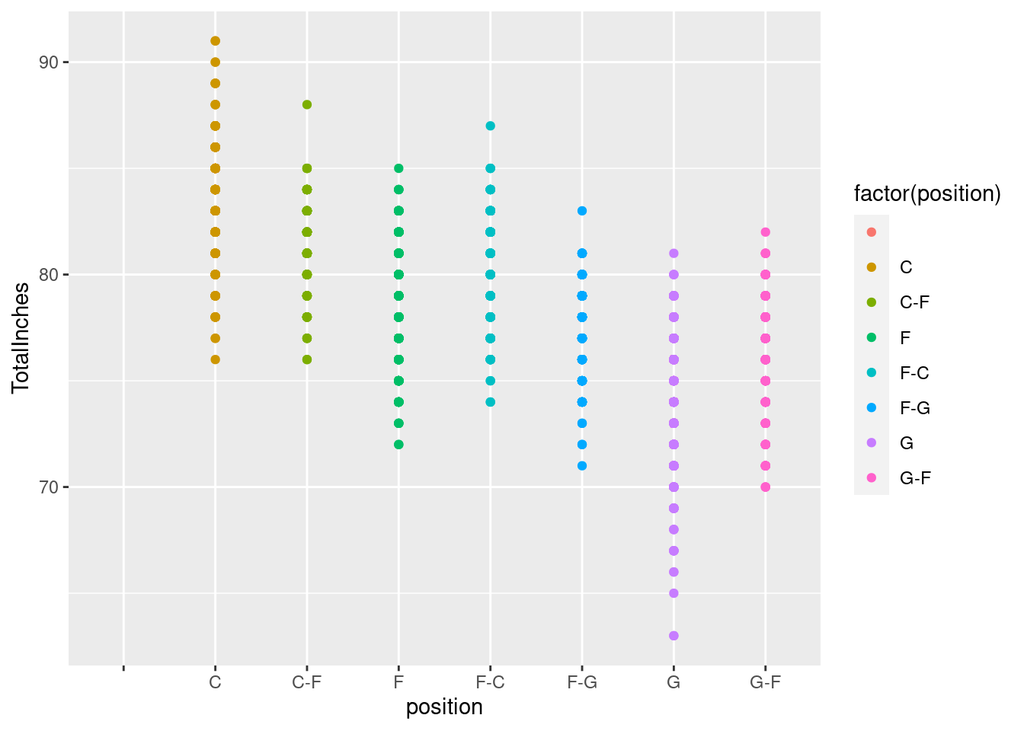

```r
library(ggplot2)
# plot everything
ggplot(hello, aes(x= position, y= TotalInches))+
geom_point(aes(colour = factor(position)))
```

##part2. We previously used a dataset called FIFA Players.csv which contained information about Soccer players.  
##Use the string functions and regular expressions to assess a relationship between height and weight among soccer players. To do this you will need to manipulate the height and weight columns into columns that have numeric values of the height and weight. Tell your story using 2 – 4 PPT Slides.

```r
hello1 = read.csv("FIFA Players.csv")
head(hello1)
```

```
##   X     ID              Name Age                                          Photo
## 1 0 158023          L. Messi  31 https://cdn.sofifa.org/players/4/19/158023.png
## 2 1  20801 Cristiano Ronaldo  33  https://cdn.sofifa.org/players/4/19/20801.png
## 3 2 190871         Neymar Jr  26 https://cdn.sofifa.org/players/4/19/190871.png
## 4 3 193080            De Gea  27 https://cdn.sofifa.org/players/4/19/193080.png
## 5 4 192985      K. De Bruyne  27 https://cdn.sofifa.org/players/4/19/192985.png
## 6 5 183277         E. Hazard  27 https://cdn.sofifa.org/players/4/19/183277.png
##   Nationality                                Flag Overall Potential
## 1   Argentina https://cdn.sofifa.org/flags/52.png      94        94
## 2    Portugal https://cdn.sofifa.org/flags/38.png      94        94
## 3      Brazil https://cdn.sofifa.org/flags/54.png      92        93
## 4       Spain https://cdn.sofifa.org/flags/45.png      91        93
## 5     Belgium  https://cdn.sofifa.org/flags/7.png      91        92
## 6     Belgium  https://cdn.sofifa.org/flags/7.png      91        91
##                  Club                                    Club.Logo   Value
```

[output cut: 76 more lines]

```r
library(tidyr)
library(dplyr)
df <- separate(data = hello1, col = Height, into = c("ft", "inch"), sep = "\\'")
ft_numeric <- as.numeric(df$ft)
head(ft_numeric)
```

```
## [1] 5 6 5 6 5 5
```

```r
inch_numeric <- as.numeric(df$inch)
TotalInches <- ft_numeric*12+inch_numeric
hello1$TotalInches <- TotalInches
hello1$Weight <- gsub("\\lbs","",hello1$Weight)
head(hello1)
```

```
##   X     ID              Name Age                                          Photo
## 1 0 158023          L. Messi  31 https://cdn.sofifa.org/players/4/19/158023.png
## 2 1  20801 Cristiano Ronaldo  33  https://cdn.sofifa.org/players/4/19/20801.png
## 3 2 190871         Neymar Jr  26 https://cdn.sofifa.org/players/4/19/190871.png
## 4 3 193080            De Gea  27 https://cdn.sofifa.org/players/4/19/193080.png
## 5 4 192985      K. De Bruyne  27 https://cdn.sofifa.org/players/4/19/192985.png
## 6 5 183277         E. Hazard  27 https://cdn.sofifa.org/players/4/19/183277.png
##   Nationality                                Flag Overall Potential
## 1   Argentina https://cdn.sofifa.org/flags/52.png      94        94
## 2    Portugal https://cdn.sofifa.org/flags/38.png      94        94
## 3      Brazil https://cdn.sofifa.org/flags/54.png      92        93
## 4       Spain https://cdn.sofifa.org/flags/45.png      91        93
## 5     Belgium  https://cdn.sofifa.org/flags/7.png      91        92
## 6     Belgium  https://cdn.sofifa.org/flags/7.png      91        91
##                  Club                                    Club.Logo   Value
```

[output cut: 76 more lines]

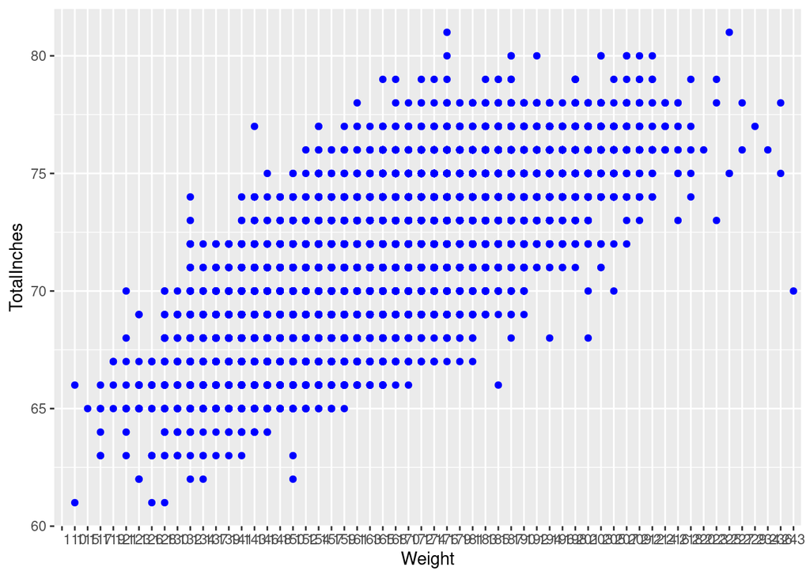

```r
hello1 %>% ggplot(aes(x = Weight, y = TotalInches)) +
geom_point(color = "blue")
```

##Next, assess this relationship between just the LB and LM positions. (1 slide should do it.)

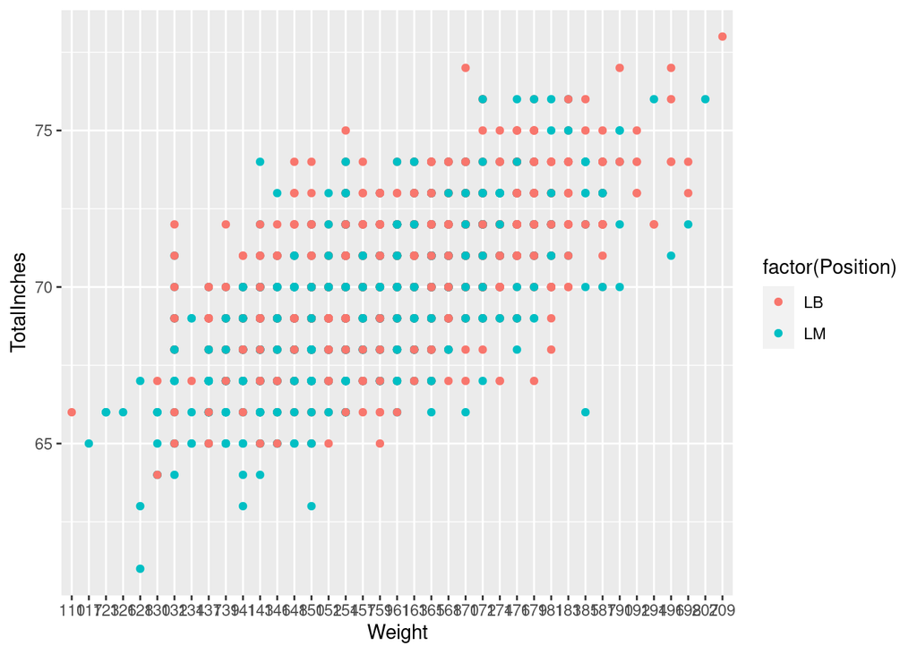

```r
df <- filter(hello1,Position == "LB" | Position == "LM")
df %>% ggplot(aes(x = Weight, y = TotalInches)) +
geom_point(aes(colour = factor(Position)))
```

### Data Munging (30 points): Utilize yob2016.txt for this question. This file is a series of popular children’s names born in the year 2016 in the United States. It consists of three columns with a first name, a gender, and the amount of children given that name. However, the data is raw and will need cleaning to make it tidy and usable. ##First, import the .txt file into R so you can process it. Keep in mind this is not a CSV file. You might have to open the file to see what you’re dealing with. Assign the resulting data frame to an object, df, that consists of three columns with human-readable column names for each. ##Display the summary and structure of df

```r
hello2 <- read.csv("yob2016.txt",sep = ";")
names(hello2) <- c("name", "gender","count" )
head(hello2)
```

```
##        name gender count
## 1    Olivia      F 19246
## 2       Ava      F 16237
## 3    Sophia      F 16070
## 4  Isabella      F 14722
## 5       Mia      F 14366
## 6 Charlotte      F 13030
```

##Your client tells you that there is a problem with the raw file. One name was entered twice and misspelled. The client cannot remember which name it is; there are thousands he saw! But he did mention he accidentally put three y’s at the end of the name. Write an R command to figure out which name it is and display it.

```r
#install.packages("stringr")                        # Install stringr package
library("stringr")

#str_detect(hello2$name,"yyy") #no good
writeLines(hello2$name[grepl("yyy",hello2$name)])
```

```
## Fionayyy
```

##Upon finding the misspelled name, please remove this particular observation, as the client says it’s redundant. Save the remaining dataset as an object: y2016

```r
library(tidyverse)
y2016 <- filter(hello2, !name =="Fionayyy")
head(y2016)
```

```
##        name gender count
## 1    Olivia      F 19246
## 2       Ava      F 16237
## 3    Sophia      F 16070
## 4  Isabella      F 14722
## 5       Mia      F 14366
## 6 Charlotte      F 13030
```

```r
writeLines(y2016$name[grepl("yyy",y2016$name)])
```

##2. Data Merging (30 points): Utilize yob2015.txt for this question. This file is similar to yob2016, but contains names, gender, and total children given that name for the year 2015. ##Like 1a, please import the .txt file into R. Look at the file before you do. You might have to change some options to import it properly. Again, please give the dataframe human-readable column names. Assign the dataframe to y2015.

```r
y2015 <- read.csv("yob2015.txt",sep = ",")
names(y2015) <- c("name", "gender","count" )
head(y2015)
```

```
##       name gender count
## 1   Olivia      F 19638
## 2   Sophia      F 17381
## 3      Ava      F 16340
## 4 Isabella      F 15574
## 5      Mia      F 14871
## 6  Abigail      F 12371
```

##Display the last ten rows in the dataframe. Describe something you find interesting about these 10 rows.

```r
tail(y2015,n=10)
```

```
##         name gender count
## 33053   Ziyu      M     5
## 33054   Zoel      M     5
## 33055  Zohar      M     5
## 33056 Zolton      M     5
## 33057   Zyah      M     5
## 33058 Zykell      M     5
## 33059 Zyking      M     5
## 33060  Zykir      M     5
## 33061  Zyrus      M     5
## 33062   Zyus      M     5
```

##Merge y2016 and y2015 by your Name column; assign it to final. The client only cares about names that have data for both 2016 and 2015; there should be no NA values in either of your amount of children rows after merging.

```r
final <- merge(y2015,y2016, by = "name")
head(final)
```

```
##        name gender.x count.x gender.y count.y
## 1     Aaban        M      15        M       9
## 2     Aabha        F       7        F       7
## 3 Aabriella        F       5        F      11
## 4     Aadam        M      22        M      18
## 5   Aadarsh        M      15        M      11
## 6     Aaden        M     297        M     194
```

##3. Data Summary (30 points): Utilize your data frame object final for this part. ##Create a new column called “Total” in final that adds the amount of children in 2015 and 2016 together. In those two years combined, how many people were given popular names?

```r
final$total <- final$count.x+final$count.y
head(final)
```

```
##        name gender.x count.x gender.y count.y total
## 1     Aaban        M      15        M       9    24
## 2     Aabha        F       7        F       7    14
## 3 Aabriella        F       5        F      11    16
## 4     Aadam        M      22        M      18    40
## 5   Aadarsh        M      15        M      11    26
## 6     Aaden        M     297        M     194   491
```

###Sort the data by Total. What are the top 10 most popular names?

```r
df <- final[order(final$total,decreasing = TRUE),]
head(df,n=10)
```

```
##           name gender.x count.x gender.y count.y total
## 23603   Olivia        F   19638        F   19246 38884
## 23255     Noah        M   19594        M   19015 38609
## 19275     Liam        M   18330        M   18138 36468
## 27779   Sophia        F   17381        F   16070 33451
## 3725       Ava        F   16340        F   16237 32577
## 21098    Mason        M   16591        M   15192 31783
## 30125  William        M   15863        M   15668 31531
## 13051    Jacob        M   15914        M   14416 30330
## 12695 Isabella        F   15574        F   14722 30296
## 13574    James        M   14773        M   14776 29549
```

###The client is expecting a girl! Omit boys and give the top 10 most popular girl’s names.

```r
dff <- filter(df, gender.x=="F")
dfff <- head(dff,n=10)
dfff
```

```
##         name gender.x count.x gender.y count.y total
## 1     Olivia        F   19638        F   19246 38884
## 2     Sophia        F   17381        F   16070 33451
## 3        Ava        F   16340        F   16237 32577
## 4   Isabella        F   15574        F   14722 30296
## 5        Mia        F   14871        F   14366 29237
## 6  Charlotte        F   11381        F   13030 24411
## 7    Abigail        F   12371        F   11699 24070
## 8      Emily        F   11766        F   10926 22692
## 9     Harper        F   10283        F   10733 21016
## 10    Amelia        F    9838        F   10702 20540
```

###Write these top 10 girl names and their Totals to a CSV file. Leave out the other columns entirely.

```r
write.csv(dfff$name,"top10.csv")
```

###4. Data Visualization: Create a well labeled, visually appealing and informative visualization summarizing some of the results of this study.

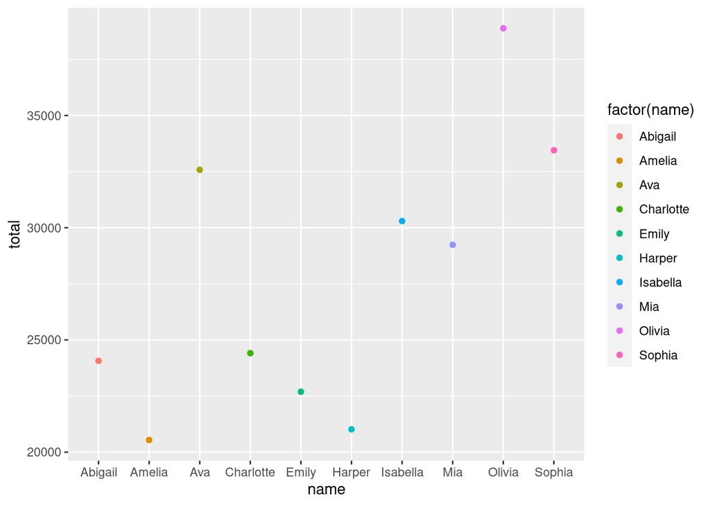

```r
ggplot(dfff, aes(x= name, y= total))+
geom_point(aes(colour = factor(name)))
```